# QR Decomposition and Orthogonalization

Biostat/Biomath M257

Author

Dr. Hua Zhou @ UCLA

Published

April 25, 2023

System information (for reproducibility):

```julia
versioninfo()
```

```
Julia Version 1.8.5
Commit 17cfb8e65ea (2023-01-08 06:45 UTC)
Platform Info:
  OS: macOS (arm64-apple-darwin21.5.0)
  CPU: 12 × Apple M2 Max
  WORD_SIZE: 64
  LIBM: libopenlibm
  LLVM: libLLVM-13.0.1 (ORCJIT, apple-m1)
  Threads: 8 on 8 virtual cores
Environment:
  JULIA_NUM_THREADS = 8
  JULIA_EDITOR = code
```

Load packages:

```julia
using Pkg

Pkg.activate(pwd())
Pkg.instantiate()
Pkg.status()
```

```
  Activating project at `~/Documents/github.com/ucla-biostat-257/2023spring/slides/13-qr`
```

```
Status `~/Documents/github.com/ucla-biostat-257/2023spring/slides/13-qr/Project.toml`
  [37e2e46d] LinearAlgebra
  [9a3f8284] Random
```

## 1 Introduction

- We learnt Cholesky decomposition as **one** approach for solving linear regression.
- A second approach for linear regression uses QR decomposition.  
  **This is how the `lm()` function in R does linear regression.**

```julia
using Random

Random.seed!(257) # seed

n, p = 5, 3
X = randn(n, p) # predictor matrix
y = randn(n)    # response vector

# now X is a tall matrix; this function finds the least squares solution
X \ y
```

```
3-element Vector{Float64}:
 0.327531097773397
 0.26321470081611203
 0.9829498789610566
```

We want to understand what is QR and how it is used to solve least squares problem.

## 2 Definition

- Assume $\mathbf{X} \in \mathbb{R}^{n \times p}$ has full column rank.
- **Full QR decomposition**:
  $$\mathbf{X} = \mathbf{Q} \mathbf{R},$$
  where
  - $\mathbf{Q} \in \mathbb{R}^{n \times n}$, $\mathbf{Q}^T \mathbf{Q} = \mathbf{I}_n$. In other words, $\mathbf{Q}$ is an orthogonal matrix.
    - First $p$ columns of $\mathbf{Q}$ form an orthonormal basis of $\mathcal{C}(\mathbf{X})$ (**column space** of $\mathbf{X}$)
    - Last $n-p$ columns of $\mathbf{Q}$ form an orthonormal basis of $\mathcal{N}(\mathbf{X}^T)$ (**null space** of $\mathbf{X}^T$)
  - $\mathbf{R} \in \mathbb{R}^{n \times p}$ is upper triangular with positive diagonal entries.
- **Skinny (or thin) QR decomposition**:
  $$\mathbf{X} = \mathbf{Q}_1 \mathbf{R}_1,$$
  where
  - $\mathbf{Q}_1 \in \mathbb{R}^{n \times p}$, $\mathbf{Q}_1^T \mathbf{Q}_1 = \mathbf{I}_p$. In other words, $\mathbf{Q}_1$ has orthonormal columns.
  - $\mathbf{R}_1 \in \mathbb{R}^{p \times p}$ is an upper triangular matrix with positive diagonal entries.
- Given QR decompositin $\mathbf{X} = \mathbf{Q} \mathbf{R}$,
  $$\mathbf{X}^T \mathbf{X} = \mathbf{R}^T \mathbf{Q}^T \mathbf{Q} \mathbf{R} = \mathbf{R}^T \mathbf{R}.$$
  Therefore $\mathbf{R}$ is the same as the upper triangular Choleksy factor of the **Gram matrix** $\mathbf{X}^T \mathbf{X}$.
- There are 3 algorithms to compute QR: (modified) Gram-Schmidt, Householder transform, (fast) Givens transform.
- In particular, the **Householder transform** for QR is implemented in LAPACK and thus used in R, Julia, Matlab, Python/Numpy, and so on.

## 3 Algorithms

### 3.1 QR by Gram-Schmidt

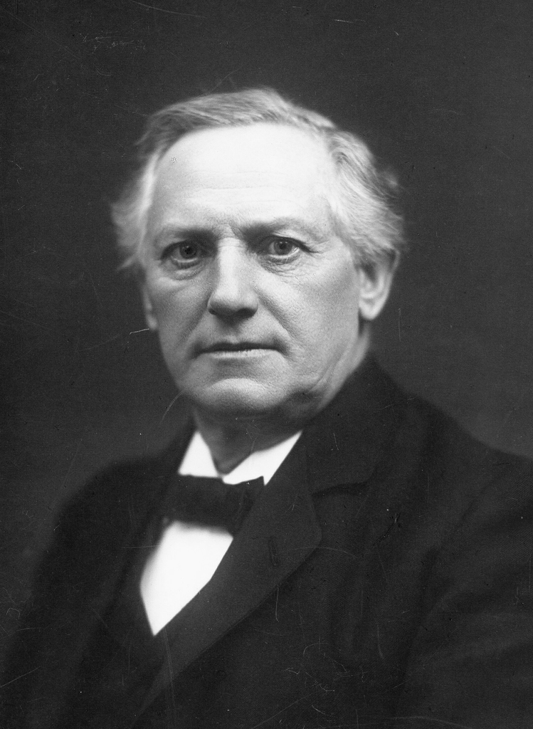

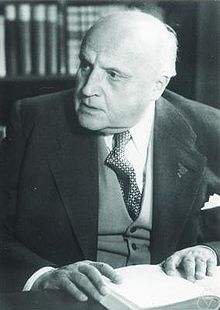

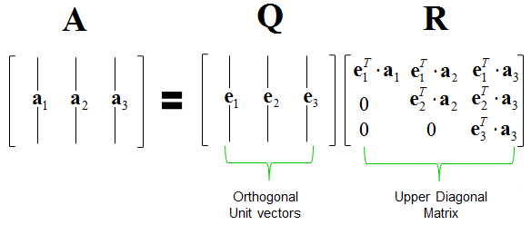

- Assume $\mathbf{X} = (\mathbf{x}_1, \ldots, \mathbf{x}_p) \in \mathbb{R}^{n \times p}$ has full column rank.
- Gram-Schmidt (GS) algorithm produces the **skinny QR**:
  $$\mathbf{X} = \mathbf{Q} \mathbf{R},$$
  where $\mathbf{Q} \in \mathbb{R}^{n \times p}$ has orthonormal columns and $\mathbf{R} \in \mathbb{R}^{p \times p}$ is an upper triangular matrix.
- **Gram-Schmidt algorithm** orthonormalizes a set of non-zero, *linearly independent* vectors $\mathbf{x}_1,\ldots,\mathbf{x}_p$.
  0. Initialize $\mathbf{q}_1 = \mathbf{x}_1 / \|\mathbf{x}_1\|_2$
  1. For $k=2, \ldots, p$,
     $$\begin{eqnarray*}
     \mathbf{v}_k &=& \mathbf{x}_k - \mathbf{P}_{\mathcal{C} \{\mathbf{q}_1,\ldots,\mathbf{q}_{k-1}\}} \mathbf{x}_k = \mathbf{x}_k - \sum_{j=1}^{k-1} \langle \mathbf{x}_k, \mathbf{q}_j \rangle \cdot \mathbf{q}_j \\
     \mathbf{q}_k &=& \mathbf{v}_k / \|\mathbf{v}_k\|_2
     \end{eqnarray*}$$
- Collectively we have $\mathbf{X} = \mathbf{Q} \mathbf{R}$.
  - $\mathbf{Q} \in \mathbb{R}^{n \times p}$ has orthonormal columns $\mathbf{q}_k$ thus $\mathbf{Q}^T \mathbf{Q} = \mathbf{I}_p$
  - Where is $\mathbf{R}$? $\mathbf{R} = \mathbf{Q}^T \mathbf{X}$ has entries $r_{jk} = \langle \mathbf{q}_j, \mathbf{x}_k \rangle$, which are computed during the Gram-Schmidt process. Note $r_{jk} = 0$ for $j > k$, so $\mathbf{R}$ is upper triangular.
- In GS algorithm, $\mathbf{X}$ is over-written by $\mathbf{Q}$ and $\mathbf{R}$ is stored in a separate array.
- The regular Gram-Schmidt is *unstable* (we loose orthogonality due to roundoff errors) when columns of $\mathbf{X}$ are collinear.
- **Modified Gram-Schmidt** (MGS): after each normalization step of $\mathbf{v}_k$, we replace columns $\mathbf{x}_j$, $j>k$, by its residual.
- Why MGS is better than GS? Read http://cavern.uark.edu/~arnold/4353/CGSMGS.pdf
- Computational cost of GS and MGS is $\sum_{k=1}^p 4n(k-1) \approx 2np^2$.

### 3.2 QR by Householder transform

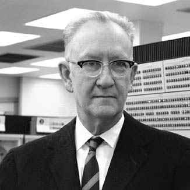

- This is the algorithm implemented in LAPACK. In other words, **this is the algorithm for solving linear regression in R**.
- Assume $\mathbf{X} = (\mathbf{x}_1, \ldots, \mathbf{x}_p) \in \mathbb{R}^{n \times p}$ has full column rank.
- Idea:
  $$\mathbf{H}_{p} \cdots \mathbf{H}_2 \mathbf{H}_1 \mathbf{X} = \begin{pmatrix} \mathbf{R}_1 \\ \mathbf{0} \end{pmatrix},$$
  where $\mathbf{H}_j \in \mathbf{R}^{n \times n}$ are a sequence of Householder transformation matrices.

  It yields the **full QR** where $\mathbf{Q} = \mathbf{H}_1 \cdots \mathbf{H}_p \in \mathbb{R}^{n \times n}$. Recall that GS/MGS only produces the **thin QR** decomposition.
- For arbitrary $\mathbf{v}, \mathbf{w} \in \mathbb{R}^{n}$ with $\|\mathbf{v}\|_2 = \|\mathbf{w}\|_2$, we can construct a **Householder matrix** (or **Householder reflector**)
  $$\mathbf{H} = \mathbf{I}_n - 2 \mathbf{u} \mathbf{u}^T, \quad \mathbf{u} = - \frac{1}{\|\mathbf{v} - \mathbf{w}\|_2} (\mathbf{v} - \mathbf{w}),$$
  that transforms $\mathbf{v}$ to $\mathbf{w}$:
  $$\mathbf{H} \mathbf{v} = \mathbf{w}.$$
  $\mathbf{H}$ is symmetric and orthogonal. Calculation of Householder vector $\mathbf{u}$ costs $4n$ flops for general $\mathbf{u}$ and $\mathbf{w}$.

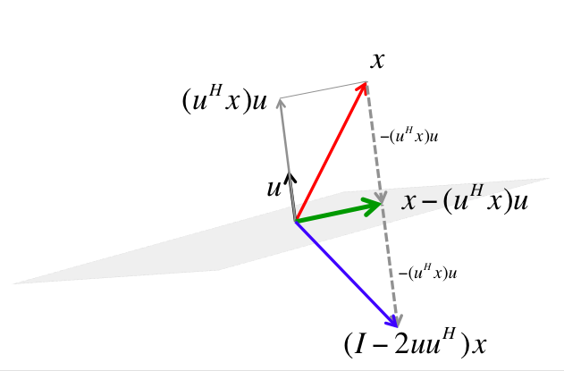

- Now choose $\mathbf{H}_1$ to zero the first column of $\mathbf{X}$ below diagonal
  $$\mathbf{H}_1 \mathbf{x}_1 = \begin{pmatrix} \|\mathbf{x}_{1}\|_2 \\ 0 \\ \vdots \\ 0 \end{pmatrix}.$$
  Take $\mathbf{H}_2$ to zero the second column below diagonal; …

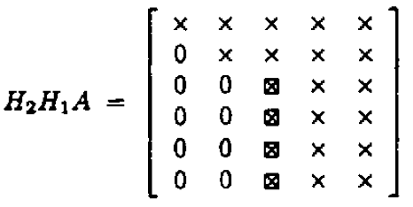

- In general, choose the $j$-th Householder transform $\mathbf{H}_j = \mathbf{I}_n - 2 \mathbf{u}_j \mathbf{u}_j^T$, where
  $$\mathbf{u}_j = \begin{pmatrix} \mathbf{0}_{j-1} \\ {\tilde u}_j \end{pmatrix}, \quad {\tilde u}_j \in \mathbb{R}^{n-j+1},$$
  to zero the $j$-th column below diagonal. $\mathbf{H}_j$ takes the form
  $$\mathbf{H}_j = \begin{pmatrix}
  \mathbf{I}_{j-1} & \\
  & \mathbf{I}_{n-j+1} - 2 {\tilde u}_j {\tilde u}_j^T
  \end{pmatrix} = \begin{pmatrix}
  \mathbf{I}_{j-1} & \\
  & {\tilde H}_{j}
  \end{pmatrix}.$$
- Applying a Householder transform $\mathbf{H} = \mathbf{I} - 2 \mathbf{u} \mathbf{u}^T$ to a matrix $\mathbf{X} \in \mathbb{R}^{n \times p}$
  $$\mathbf{H} \mathbf{X} = \mathbf{X} - 2 \mathbf{u} (\mathbf{u}^T \mathbf{X})$$
  costs $4np$ flops. **Householder updates never entail explicit formation of the Householder matrices.**
- Note applying ${\tilde H}_j$ to $\mathbf{X}$ only needs $4(n-j+1)(p-j+1)$ flops.
- QR by Householder: $\mathbf{H}_{p} \cdots \mathbf{H}_1 \mathbf{X} = \begin{pmatrix} \mathbf{R}_1 \\ \mathbf{0} \end{pmatrix}$.
- The process is done in place. Upper triangular part of $\mathbf{X}$ is overwritten by $\mathbf{R}_1$ and the essential Householder vectors ($\tilde u_{j1}$ is normalized to 1) are stored in $\mathbf{X}[j:n,j]$.
- At $j$-th stage
  0. computing the Householder vector ${\tilde u}_j$ costs $3(n-j+1)$ flops
  1. applying the Householder transform ${\tilde H}_j$ to the $\mathbf{X}[j:n, j:p]$ block costs $4(n-j+1)(p-j+1)$ flops
- In total we need
  $$\sum_{j=1}^p [3(n-j+1) + 4(n-j+1)(p-j+1)] \approx 2np^2 - \frac 23 p^3 \quad \text{flops}.$$
- Where is $\mathbf{Q}$? $\mathbf{Q} = \mathbf{H}_1 \cdots \mathbf{H}_p$. In some applications, it’s necessary to form the orthogonal matrix $\mathbf{Q}$.

  Accumulating $\mathbf{Q}$ costs another $2np^2 - \frac 23 p^3$ flops.
- When computing $\mathbf{Q}^T \mathbf{v}$ or $\mathbf{Q} \mathbf{v}$ as in some applications (e.g., solve linear equation using QR), no need to form $\mathbf{Q}$. Simply apply Householder transforms successively to the vector $\mathbf{v}$.
- Computational cost of Householder QR for linear regression: $2n p^2 - \frac 23 p^3$ (regression coefficients and $\hat \sigma^2$) or more (fitted values, s.e., …).

### 3.3 Householder QR with column pivoting

Consider rank deficient $\mathbf{X}$.

- At the $j$-th stage, swap the column in $\mathbf{X}[j:n,j:p]$ with maximum $\ell_2$ norm to be the pivot column. If the maximum $\ell_2$ norm is 0, it stops, ending with
  $$\mathbf{X} \mathbf{P} = \mathbf{Q} \begin{pmatrix} \mathbf{R}_{11} & \mathbf{R}_{12} \\ \mathbf{0}_{(n-r) \times r} & \mathbf{0}_{(n-r) \times (p-r)} \end{pmatrix},$$
  where $\mathbf{P} \in \mathbb{R}^{p \times p}$ is a permutation matrix and $r$ is the rank of $\mathbf{X}$. QR with column pivoting is rank revealing.
- The overhead of re-computing the column norms can be reduced by the property
  $$\mathbf{Q} \mathbf{z} = \begin{pmatrix} \alpha \\ \omega \end{pmatrix} \Rightarrow \|\omega\|_2^2 = \|\mathbf{z}\|_2^2 - \alpha^2$$
  for any orthogonal matrix $\mathbf{Q}$.

#### 3.3.1 LAPACK and Julia implementation

- Julia functions: qr, qr!, or call LAPACK wrapper functions geqrf! and geqp3!

```julia
using Random, LinearAlgebra

Random.seed!(257) # seed

y = randn(5)    # response vector
X = randn(5, 3) # predictor matrix
```

```
5×3 Matrix{Float64}:
  1.52556    0.67424     0.438785
 -1.69501   -1.48526    -0.535651
 -0.245347   0.196908   -0.623759
 -1.41158   -0.0191747  -0.580781
  0.270371   0.68845     1.47836
```

```julia
X \ y # least squares solution by QR
```

```
3-element Vector{Float64}:
  0.7737725680473986
 -2.1947916892054415
  0.45633734842685486
```

```julia
# same as
qr(X) \ y
```

```
3-element Vector{Float64}:
  0.773772568047398
 -2.194791689205441
  0.45633734842685486
```

```julia
cholesky(X'X) \ (X'y) # least squares solution by Cholesky
```

```
3-element Vector{Float64}:
  0.7737725680473986
 -2.194791689205442
  0.45633734842685497
```

```julia
# QR factorization with column pivoting
xqr = qr(X, Val(true))
```

```
QRPivoted{Float64, Matrix{Float64}, Vector{Float64}, Vector{Int64}}
Q factor:
5×5 LinearAlgebra.QRPackedQ{Float64, Matrix{Float64}, Vector{Float64}}:
 -0.563623    0.118209     0.0538187   0.438527    -0.687861
  0.626227   -0.0989179    0.608034    0.00744526  -0.477801
  0.0906439   0.353645    -0.406226   -0.685083    -0.482038
  0.521512    0.00836298  -0.643462    0.545328    -0.128567
 -0.0998892  -0.922555    -0.219851   -0.20228     -0.222853
R factor:
3×3 Matrix{Float64}:
 -2.70671  -1.08984  -1.37105
  0.0      -1.48446  -0.339038
  0.0       0.0      -1.08581
permutation:
3-element Vector{Int64}:
 1
 3
 2
```

```julia
xqr \ y # least squares solution
```

```
3-element Vector{Float64}:
  0.7737725680473986
 -2.1947916892054415
  0.45633734842685486
```

```julia
# thin Q matrix multiplication (a sequence of Householder transforms)
norm(xqr.Q * xqr.R - X[:, xqr.p]) # recovers X (with columns permuted)
```

```
3.368045037175248e-16
```

### 3.4 QR by Givens rotation

- Householder transform $\mathbf{H}_j$ introduces batch of zeros into a vector.
- **Givens transform** (aka **Givens rotation**, **Jacobi rotation**, **plane rotation**) selectively zeros one element of a vector.
- Overall QR by Givens rotation is less efficient than the Householder method, but is better suited for matrices with structured patterns of nonzero elements.
- **Givens/Jacobi rotations**:
  $$\mathbf{G}(i,k,\theta) = \begin{pmatrix}
  1 & & 0 & & 0 & & 0 \\
  \vdots & \ddots & \vdots & & \vdots & & \vdots \\
  0 & & c & & s & & 0 \\
  \vdots & & \vdots & \ddots & \vdots & & \vdots \\
  0 & & - s & & c & & 0 \\
  \vdots & & \vdots & & \vdots & \ddots & \vdots \\
  0 & & 0 & & 0 & & 1 \end{pmatrix},$$
  where $c = \cos(\theta)$ and $s = \sin(\theta)$. $\mathbf{G}(i,k,\theta)$ is orthogonal.
- Pre-multiplication by $\mathbf{G}(i,k,\theta)^T$ rotates counterclockwise $\theta$ radians in the $(i,k)$ coordinate plane. If $\mathbf{x} \in \mathbb{R}^n$ and $\mathbf{y} = \mathbf{G}(i,k,\theta)^T \mathbf{x}$, then
  $$y_j = \begin{cases}
  cx_i - s x_k & j = i \\
  sx_i + cx_k & j = k \\
  x_j & j \ne i, k
  \end{cases}.$$
  Apparently if we choose $\tan(\theta) = -x_k / x_i$, or equivalently,
  $$\begin{eqnarray*}
  c = \frac{x_i}{\sqrt{x_i^2 + x_k^2}}, \quad s = \frac{-x_k}{\sqrt{x_i^2 + x_k^2}},
  \end{eqnarray*}$$
  then $y_k=0$.
- Pre-applying Givens transform $\mathbf{G}(i,k,\theta)^T \in \mathbb{R}^{n \times n}$ to a matrix $\mathbf{A} \in \mathbb{R}^{n \times m}$ only effects two rows of $\mathbf{ A}$:
  $$\mathbf{A}([i, k], :) \gets \begin{pmatrix} c & s \\ -s & c \end{pmatrix}^T \mathbf{A}([i, k], :),$$
  costing $6m$ flops.
- Post-applying Givens transform $\mathbf{G}(i,k,\theta) \in \mathbb{R}^{m \times m}$ to a matrix $\mathbf{A} \in \mathbb{R}^{n \times m}$ only effects two columns of $\mathbf{A}$:
  $$\mathbf{A}(:, [i,k]) \gets \mathbf{A}(:, [i,k]) \begin{pmatrix} c & s \\ -s & c \end{pmatrix},$$
  costing $6n$ flops.
- QR by Givens: $\mathbf{G}_t^T \cdots \mathbf{G}_1^T \mathbf{X} = \begin{pmatrix} \mathbf{R}_1 \\ \mathbf{0} \end{pmatrix}$.

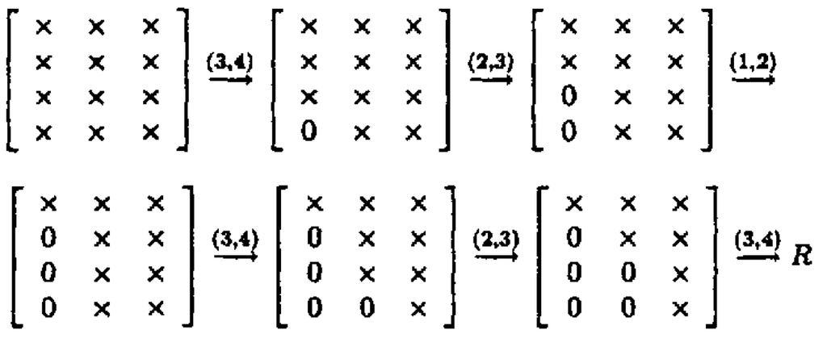

- Zeros in $\mathbf{X}$ can also be introduced row-by-row.
- If $\mathbf{X} \in \mathbb{R}^{n \times p}$, the total cost is $3np^2 - p^3$ flops and $O(np)$ square roots.
- Note each Givens transform can be summarized by a single number, which is stored in the zeroed entry of $\mathbf{X}$.
- *Fast Givens transform* avoids taking square roots.

## 5 Further reading

- Section 7.8 of [Numerical Analysis for Statisticians](http://ucla.worldcat.org/title/numerical-analysis-for-statisticians/oclc/793808354&referer=brief_results) of Kenneth Lange (2010).
- Section II.5.3 of [Computational Statistics](http://ucla.worldcat.org/title/computational-statistics/oclc/437345409&referer=brief_results) by James Gentle (2010).
- Chapter 5 of [Matrix Computation](https://search.library.ucla.edu/permalink/01UCS_LAL/17p22dp/alma9971220883606533) by Gene Golub and Charles Van Loan (2013).